# Case 31: Employees Federal Credit Union

IC11-2 · Summary of Data Analysis: R1, R2, R5 & R6

Simran Kaur

IBM 6500 · Cal Poly Pomona

2026-11-07

## About the study

- **Who:** **128 members** of the Employees Federal Credit Union (EFCU) who returned the **mail survey** (Case Exhibit 31.1)
- **Data:** cleaned file `Case 31 Data_efcu_4.sav`. Items ending in **r** are **reverse-coded**, so **higher = more**
- **Approach:** **descriptive statistics first** (frequencies, means, medians, skewness), then **the story**, then an **inferential test to confirm it**. Test results stay **in parentheses** so they don’t get in the way

**Note**

**Q2 (“why did you join”) and Q28–Q29 (“why borrow elsewhere”) were not coded in the data file.** Following the data analysis table, **R1** uses opinions of the CU’s **savings rates (Q7r)**, and **R2** uses **loan rates (Q8r)**, with **Q30, Q32 and Q34** as supporting evidence.

# R1: Why do people join the Credit Union?

## R1 · Descriptive statistics

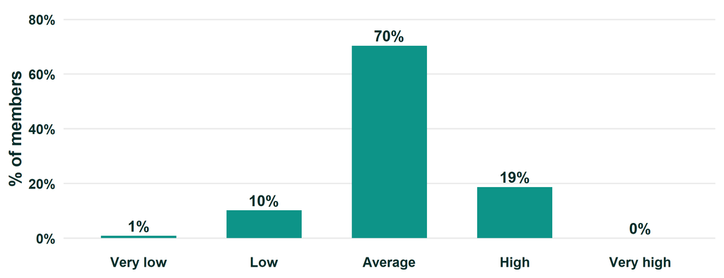

Figure 1: Opinion of the rates the CU pays on share (savings) accounts (Q7r)

Table 1: Descriptive statistics for Q7r (1 = very low, 5 = very high)

| Item | n | Mean | SD | Median | Skew |
| --- | --- | --- | --- | --- | --- |
| Q7r: Savings rates paid | 118 | 3.07 | 0.57 | 3 | -0.26 |

## R1 · Insight and one-sample t-test

**Savings rates are NOT a strong reason to join EFCU.**

- **7 in 10 members (70%)** call the savings rates just **“average”**. Only **19%** think they’re **high** (Figure 1)
- The average opinion sits **right at the midpoint**, with **no real difference from “average”** (*M* = 3.07, *t*(117) = 1.30, *p* = 0.196; Table 2)
- **So what:** members likely join for **convenience, the personal feel, or easy loans**, not savings returns. **Don’t market on savings rates.**

Table 2: One-sample t-test: Q7r against the scale midpoint (3 = average)

| Item | Test value | Mean | t | df | p |
| --- | --- | --- | --- | --- | --- |
| Q7r: Savings rates paid | 3 | 3.07 | 1.3 | 117 | 0.196 |

# R2: Why do members borrow elsewhere?

## R2 · Descriptive statistics

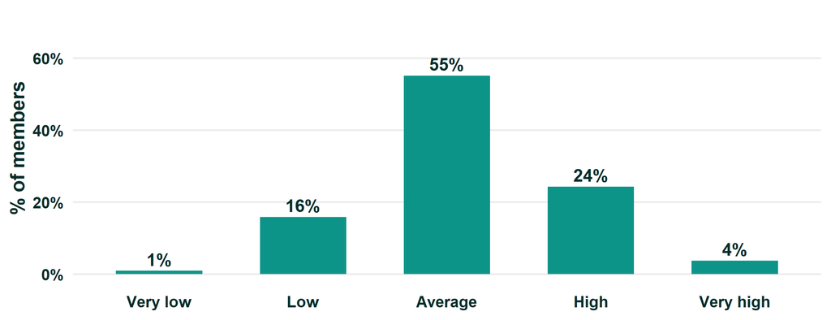

Figure 2: Opinion of the rates the CU charges to borrow (Q8r)

Table 3: Descriptive statistics for loan-related items (Q8r: 5 = very high rates; Q30–Q34: 5 = strongly agree)

| Item | n | Mean | SD | Median | Skew |
| --- | --- | --- | --- | --- | --- |
| Q8r: Loan rates charged are high | 107 | 3.14 | 0.76 | 3 | 0.15 |
| Q30: CU loan rates lower than others | 128 | 3.06 | 0.87 | 3 | -0.05 |
| Q32: CU is prompt processing loans | 128 | 3.72 | 0.79 | 4 | -0.03 |
| Q34: Loan applications simple and easy | 128 | 3.46 | 0.78 | 4 | -0.90 |

## R2 · Insight and one-sample t-tests

**Members borrow elsewhere for PRICE, not service.**

- **Only 17%** think CU loan rates are **low**, while **28%** think they’re **high** (Figure 2)
- Do CU rates **beat other lenders?** Members are **split down the middle** (Q30 *M* = 3.06, *p* = 0.416; Table 4)
- The **loan process is NOT the problem**: loans are handled **promptly** (Q32, *p* < .001) and applications are **easy** (Q34, *p* < .001)
- **Fewer than half (45%) have a CU loan**, a split that’s **no different from 50/50** (χ²(1) = 1.12, *p* = 0.289; Table 5). So **more than half don’t currently borrow from EFCU**
- **So what:** **competitive loan pricing is EFCU’s clearest growth lever.**

Table 4: One-sample t-tests against the scale midpoint (3)

| Item | Test value | Mean | t | df | p |
| --- | --- | --- | --- | --- | --- |
| Q8r: Loan rates charged are high | 3 | 3.14 | 1.91 | 106 | 0.058 |
| Q30: CU loan rates lower than others | 3 | 3.06 | 0.82 | 127 | 0.416 |
| Q32: CU is prompt processing loans | 3 | 3.72 | 10.25 | 127 | < .001 |
| Q34: Loan applications simple and easy | 3 | 3.46 | 6.66 | 127 | < .001 |

Table 5: Q27: Currently have a loan with the CU (chi-square goodness-of-fit, equal proportions)

| Response | n | Percent | Chi-square | df | p |
| --- | --- | --- | --- | --- | --- |
| Yes | 58 | 45.31 | 1.12 | 1 | 0.289 |
| No | 70 | 54.69 |  |  |  |

# R5: How aware are members of EFCU’s services?

## R5 · Descriptive statistics

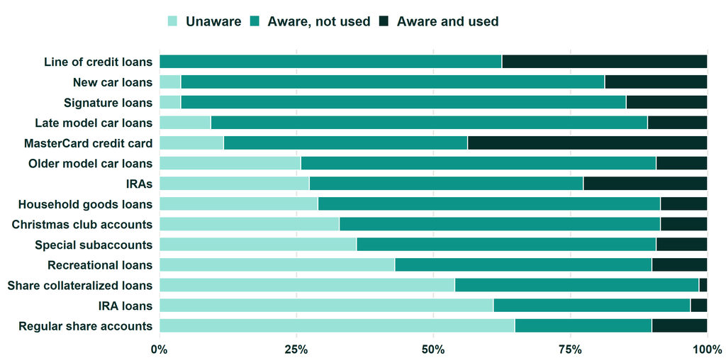

Figure 3: Awareness of each EFCU service (% of members)

## R5 · Awareness by service

Table 6: Awareness of services: frequencies and percentages, sorted by % unaware

| Service | Unaware | Aware, not used | Aware and used |
| --- | --- | --- | --- |
| Regular share accounts | 83 (65%) | 32 (25%) | 13 (10%) |
| IRA loans | 78 (61%) | 46 (36%) | 4 (3%) |
| Share collateralized loans | 69 (54%) | 57 (45%) | 2 (2%) |
| Recreational loans | 55 (43%) | 60 (47%) | 13 (10%) |
| Special subaccounts | 46 (36%) | 70 (55%) | 12 (9%) |
| Christmas club accounts | 42 (33%) | 75 (59%) | 11 (9%) |
| Household goods loans | 37 (29%) | 80 (62%) | 11 (9%) |
| IRAs | 35 (27%) | 64 (50%) | 29 (23%) |
| Older model car loans | 33 (26%) | 83 (65%) | 12 (9%) |
| MasterCard credit card | 15 (12%) | 57 (45%) | 56 (44%) |
| Late model car loans | 12 (9%) | 102 (80%) | 14 (11%) |
| Signature loans | 5 (4%) | 104 (81%) | 19 (15%) |
| New car loans | 5 (4%) | 99 (77%) | 24 (19%) |
| Line of credit loans | 0 (0%) | 80 (62%) | 48 (38%) |

## R5 · Insight and chi-square goodness-of-fit

**Members know the LOAN products, but not the savings and retirement extras.**

- **New car loans, signature loans and lines of credit:** almost **universally known (96%+ aware)**
- **Never heard of:** **IRA loans (61%)**, **share-collateralized loans (54%)**, **recreational loans (43%)**, **special subaccounts (36%)**, **Christmas club (33%)** (Table 6)
- **Awareness rarely turns into use.** Only the **MasterCard (44% used)** and **line of credit (38%)** have real uptake (Figure 3)
- **Not chance:** every service is far from an even split (all χ²(2) ≥ 16.4, *p* < .001; Table 7)
- **Red flag:** **65% say they’re “unaware” of regular share accounts**, which every member needs to join. Members likely **don’t recognize the term**, which is a **communication problem** in itself

Table 7: Chi-square goodness-of-fit tests (equal proportions across the three awareness levels)

| Service | Chi-square | df | p |
| --- | --- | --- | --- |
| Regular share accounts | 61.42 | 2 | < .001 |
| Special subaccounts | 39.81 | 2 | < .001 |
| Christmas club accounts | 48.02 | 2 | < .001 |
| IRAs | 16.42 | 2 | < .001 |
| MasterCard credit card | 26.92 | 2 | < .001 |
| Signature loans | 134.55 | 2 | < .001 |
| New car loans | 115.80 | 2 | < .001 |
| Late model car loans | 123.81 | 2 | < .001 |
| Older model car loans | 62.36 | 2 | < .001 |
| Household goods loans | 56.92 | 2 | < .001 |
| Recreational loans | 31.23 | 2 | < .001 |
| Share collateralized loans | 59.83 | 2 | < .001 |
| IRA loans | 64.56 | 2 | < .001 |
| Line of credit loans | 76.00 | 2 | < .001 |

# R6: How effectively is the Credit Union operated?

## R6 · Statements (Q9, Q10, Q11)

Table 8: Member opinions about account statements

| Item | Response | n | Percent |
| --- | --- | --- | --- |
| Q9: Statement frequency | About right | 99 | 77.3 |
| Q9: Statement frequency | Not often enough | 29 | 22.7 |
| Q10: Statement accuracy | Excellent | 68 | 53.1 |
| Q10: Statement accuracy | Good | 54 | 42.2 |
| Q10: Statement accuracy | Fair | 4 | 3.1 |
| Q10: Statement accuracy | Poor | 2 | 1.6 |
| Q11: Easy to understand | Yes | 125 | 97.7 |
| Q11: Easy to understand | No | 3 | 2.3 |
| Q12: Info kept confidential | Yes | 74 | 69.8 |
| Q12: Info kept confidential | No | 32 | 30.2 |

**Statements work well, with ONE exception: frequency.**

- **98% find them easy to understand** (χ²(1) = 116.3, *p* < .001)
- **95% rate accuracy good or excellent** (Q10r *M* = 3.47 of 4; *t*(127) = 17.15, *p* < .001)
- But **23% say statements don’t come often enough**, and **nobody** says too often (χ²(1) = 38.3, *p* < .001; Table 8)
- **So what:** **send statements more often.** It’s an easy fix

## R6 · Confidentiality (Q12, Q31)

**Most members trust EFCU with their information, but there’s real doubt.**

- **78% agree** staff keep their financial information **confidential**, and **only one member disagrees** (Q31 *M* = 3.95; *t*(127) = 15.74, *p* < .001; Table 9)
- But on the **yes/no version (Q12)**, **30% said NO**, and **22 members (17%) skipped it** (χ²(1) = 16.6, *p* < .001; Table 8)
- **So what:** almost **a third saying “no” to a basic privacy question** is a **warning sign** for a financial institution

## R6 · Operations items (Q31–Q34) and overall rating (Q37r)

Table 9: Descriptive statistics for operational effectiveness items (5 = strongly agree / excellent)

| Item | n | Mean | SD | Median | Skew | % agree / good+ |
| --- | --- | --- | --- | --- | --- | --- |
| Q31: Personnel keep info confidential | 128 | 3.95 | 0.68 | 4 | -0.53 | 78 |
| Q32: Prompt in processing loans | 128 | 3.72 | 0.79 | 4 | -0.03 | 60 |
| Q33: Services meet members’ needs | 128 | 3.59 | 0.68 | 4 | -0.34 | 59 |
| Q34: Loan applications simple | 128 | 3.46 | 0.78 | 4 | -0.90 | 58 |
| Q37r: Overall management & operation | 121 | 4.07 | 0.73 | 4 | -0.87 | 84 |

Table 10: One-sample t-tests against the scale midpoint (3)

| Item | Test value | Mean | t | df | p |
| --- | --- | --- | --- | --- | --- |
| Q31: Personnel keep info confidential | 3 | 3.95 | 15.74 | 127 | < .001 |
| Q32: Prompt in processing loans | 3 | 3.72 | 10.25 | 127 | < .001 |
| Q33: Services meet members’ needs | 3 | 3.59 | 9.87 | 127 | < .001 |
| Q34: Loan applications simple | 3 | 3.46 | 6.66 | 127 | < .001 |
| Q37r: Overall management & operation | 3 | 4.07 | 16.12 | 120 | < .001 |

## R6 · Insight

**Members think EFCU is WELL RUN.**

- **84% rate overall management good or excellent** (Q37r *M* = 4.07; *t*(120) = 16.12, *p* < .001)
- **Every operational item is well above neutral** (all *p* < .001; Table 10). **Confidentiality** scores **highest**, then **prompt loan processing**
- **Weakest spots:** **meeting members’ needs** (Q33, **59% agree**) and **simple loan applications** (Q34, **58% agree**, **12% disagree**)
- These four items **don’t form one scale** (α = 0.47), so **each is read on its own**. Members judge **privacy, speed, fit and paperwork separately**

# Summary

## What the data tell EFCU

|  | Finding | So what |
| --- | --- | --- |
| **R1** | Savings rates are just **“average” (70%)** | **Don’t market on savings rates** |
| **R2** | Loan rates seen as **average-to-high**. The loan **process is rated well** | Members borrow elsewhere for **price**. **Competitive loan rates** are the lever |
| **R5** | Loan products **well known**. **IRA loans, share-collateralized loans** and **savings extras unknown to 33–61%** | **Targeted communication.** Clarify what a **“share account”** is |
| **R6** | **84% rate EFCU good or excellent.** Statements **clear and accurate** | **Send statements more often (23%)**. **Review privacy messaging (30% “no”)** |

## Appendix: R code

```r
library(tidyverse)
library(haven)
library(labelled)
library(psych)
library(knitr)
options(knitr.kable.NA = "")

blue      <- "#0D9488"   # teal, matches the deck theme
aware_pal <- c("Unaware" = "#99E2D8", "Aware, not used" = "#0D9488", "Aware and used" = "#052E2B")

theme_set(
  theme_minimal(base_size = 22, base_family = "sans") +
    theme(panel.grid.major.x = element_blank(),
          panel.grid.minor   = element_blank(),
          plot.title.position = "plot",
          axis.text  = element_text(color = "#052E2B", face = "bold"),
          axis.title = element_text(color = "#052E2B", face = "bold"),
          legend.text = element_text(color = "#052E2B", face = "bold", size = 20))
)

efcu <- read_sav("Case 31 Data_efcu_4.sav")
d    <- zap_labels(efcu) |>
  mutate(q12 = na_if(q12, 3))          # 3 = "No answer" -> missing

# descriptive row for one interval item
desc_row <- function(x, item) {
  x <- na.omit(as.numeric(x))
  tibble(Item = item, n = length(x), Mean = mean(x), SD = sd(x),
         Median = median(x), Skew = psych::skew(x))
}

# one-sample t-test row
t_row <- function(x, item, mu = 3) {
  tt <- t.test(na.omit(as.numeric(x)), mu = mu)
  tibble(Item = item, `Test value` = mu, Mean = unname(tt$estimate),
         t = unname(tt$statistic), df = unname(tt$parameter), p = tt$p.value)
}

fmt_p <- function(p) ifelse(p < .001, "< .001", sprintf("%.3f", p))

# frequency table with percent
freq_pct <- function(x, labels) {
  tibble(code = as.numeric(x)) |>
    filter(!is.na(code)) |>
    count(code) |>
    mutate(Response = labels[as.character(code)], Percent = 100 * n / sum(n)) |>
    select(Response, n, Percent)
}
q7_labels <- c("1" = "Very low", "2" = "Low", "3" = "Average", "4" = "High", "5" = "Very high")
q7_tab <- freq_pct(d$Q7_r, q7_labels) |>
  right_join(tibble(Response = q7_labels), by = "Response") |>
  mutate(n = replace_na(n, 0), Percent = replace_na(Percent, 0),
         Response = factor(Response, levels = q7_labels))

ggplot(q7_tab, aes(Response, Percent)) +
  geom_col(fill = blue, width = 0.6) +
  geom_text(aes(label = sprintf("%.0f%%", Percent)), vjust = -0.4, color = "#052E2B", size = 7, fontface = "bold") +
  scale_y_continuous(limits = c(0, 80), labels = \(x) paste0(x, "%")) +
  labs(x = NULL, y = "% of members")
desc_row(d$Q7_r, "Q7r: Savings rates paid") |> kable(digits = 2)
t_row(d$Q7_r, "Q7r: Savings rates paid") |>
  mutate(p = fmt_p(p)) |>
  kable(digits = 2)
q8_tab <- freq_pct(d$Q8_r, q7_labels) |>
  mutate(Response = factor(Response, levels = q7_labels))

ggplot(q8_tab, aes(Response, Percent)) +
  geom_col(fill = blue, width = 0.6) +
  geom_text(aes(label = sprintf("%.0f%%", Percent)), vjust = -0.4, color = "#052E2B", size = 7, fontface = "bold") +
  scale_y_continuous(limits = c(0, 70), labels = \(x) paste0(x, "%")) +
  labs(x = NULL, y = "% of members")
bind_rows(
  desc_row(d$Q8_r, "Q8r: Loan rates charged are high"),
  desc_row(d$q30,  "Q30: CU loan rates lower than others"),
  desc_row(d$q32,  "Q32: CU is prompt processing loans"),
  desc_row(d$q34,  "Q34: Loan applications simple and easy")
) |> kable(digits = 2)
bind_rows(
  t_row(d$Q8_r, "Q8r: Loan rates charged are high"),
  t_row(d$q30,  "Q30: CU loan rates lower than others"),
  t_row(d$q32,  "Q32: CU is prompt processing loans"),
  t_row(d$q34,  "Q34: Loan applications simple and easy")
) |>
  mutate(p = fmt_p(p)) |>
  kable(digits = 2)
q27_ct <- chisq.test(table(d$q27))
freq_pct(d$q27, c("1" = "Yes", "2" = "No")) |>
  mutate(`Chi-square` = c(unname(q27_ct$statistic), NA),
         df = c(unname(q27_ct$parameter), NA),
         p  = c(fmt_p(q27_ct$p.value), "")) |>
  kable(digits = 2)
services <- c(
  q13_r = "Regular share accounts", q14_r = "Special subaccounts",
  q15_r = "Christmas club accounts", q16_r = "IRAs",
  q17_r = "MasterCard credit card", q18_r = "Signature loans",
  q19_r = "New car loans", q20_r = "Late model car loans",
  q21_r = "Older model car loans", q22_r = "Household goods loans",
  q23_r = "Recreational loans", q24_r = "Share collateralized loans",
  q25_r = "IRA loans", q26_r = "Line of credit loans"
)
aware_levels <- c("1" = "Unaware", "2" = "Aware, not used", "3" = "Aware and used")

aware_long <- d |>
  select(all_of(names(services))) |>
  pivot_longer(everything(), names_to = "item", values_to = "code") |>
  filter(!is.na(code)) |>
  count(item, code) |>
  group_by(item) |>
  mutate(Percent = 100 * n / sum(n)) |>
  ungroup() |>
  mutate(Service = services[item],
         Level   = factor(aware_levels[as.character(code)], levels = aware_levels))

aware_order <- aware_long |>
  filter(Level == "Unaware") |>
  right_join(tibble(Service = unname(services)), by = "Service") |>
  mutate(Percent = replace_na(Percent, 0)) |>
  arrange(desc(Percent)) |>
  pull(Service)
aware_long |>
  mutate(Service = factor(Service, levels = aware_order),
         Level = fct_rev(Level)) |>
  ggplot(aes(Percent, Service, fill = Level)) +
  geom_col(width = 0.7, color = "white", linewidth = 0.8) +
  scale_fill_manual(values = aware_pal, breaks = names(aware_pal)) +
  scale_x_continuous(labels = \(x) paste0(x, "%"), expand = expansion(mult = c(0, 0.02))) +
  labs(x = NULL, y = NULL, fill = NULL) +
  theme(legend.position = "top", legend.justification = "left",
        panel.grid.major.y = element_blank(), panel.grid.major.x = element_line(color = "#e8e7e3"))
aware_long |>
  select(Service, Level, n, Percent) |>
  mutate(cell = sprintf("%d (%.0f%%)", n, Percent)) |>
  select(Service, Level, cell) |>
  pivot_wider(names_from = Level, values_from = cell, values_fill = "0 (0%)") |>
  select(Service, all_of(unname(aware_levels))) |>
  mutate(Service = factor(Service, levels = aware_order)) |>
  arrange(Service) |>
  kable()
map_dfr(names(services), function(v) {
  tab <- table(factor(d[[v]], levels = 1:3))
  ct  <- chisq.test(tab)
  tibble(Service = services[[v]], `Chi-square` = unname(ct$statistic),
         df = unname(ct$parameter), p = fmt_p(ct$p.value))
}) |>
  kable(digits = 2)
bind_rows(
  freq_pct(d$q9,  c("1" = "Too often", "2" = "Very often", "3" = "About right",
                    "4" = "Not often enough", "5" = "Never")) |> mutate(Item = "Q9: Statement frequency"),
  freq_pct(d$q10, c("1" = "Excellent", "2" = "Good", "3" = "Fair", "4" = "Poor")) |>
    mutate(Item = "Q10: Statement accuracy"),
  freq_pct(d$q11, c("1" = "Yes", "2" = "No")) |> mutate(Item = "Q11: Easy to understand"),
  freq_pct(d$q12, c("1" = "Yes", "2" = "No")) |> mutate(Item = "Q12: Info kept confidential")
) |>
  select(Item, Response, n, Percent) |>
  kable(digits = 1)
bind_rows(
  desc_row(d$q31,   "Q31: Personnel keep info confidential"),
  desc_row(d$q32,   "Q32: Prompt in processing loans"),
  desc_row(d$q33,   "Q33: Services meet members' needs"),
  desc_row(d$q34,   "Q34: Loan applications simple"),
  desc_row(d$Q37_r, "Q37r: Overall management & operation")
) |>
  mutate(`% agree / good+` = c(
    100 * mean(d$q31 >= 4), 100 * mean(d$q32 >= 4), 100 * mean(d$q33 >= 4),
    100 * mean(d$q34 >= 4), 100 * mean(d$Q37_r >= 4, na.rm = TRUE))) |>
  mutate(`% agree / good+` = round(`% agree / good+`)) |>
  kable(digits = 2)
ops_alpha <- psych::alpha(as.data.frame(d[, c("q31", "q32", "q33", "q34")]))
bind_rows(
  t_row(d$q31,   "Q31: Personnel keep info confidential"),
  t_row(d$q32,   "Q32: Prompt in processing loans"),
  t_row(d$q33,   "Q33: Services meet members' needs"),
  t_row(d$q34,   "Q34: Loan applications simple"),
  t_row(d$Q37_r, "Q37r: Overall management & operation")
) |>
  mutate(p = fmt_p(p)) |>
  kable(digits = 2)
```

## Appendix: Links

- **GitHub Pages:** (https://simrank-dm.github.io/IBM6500-F26/IC11-2-Case%2031-%20Summary%20of%20Data%20Analysis-R1-R2-R5-R6/IC11-2-Case31-Summary-Simran-Kaur.html)
- **GitHub Repository:** https://github.com/Simrank-DM/IBM-case31-data-prep